# Assignment 3

Sonali Singh

# Knowledge Mining: Linear Discriminant Analysis

File: Lab_LDA01.R Theme: Linear Discriminant Analysis Adapted from ISLR Chapter 4 Lab

### **Overview**

In this assignment, the TEDS_2016 dataset was used to explore the relationships between various demographic and economic variables with political preferences in Taiwan. The analysis involved running multiple regression models to understand these relationships and the development of a custom function for plotting regression analyses.

### **Data Summary**

The dataset consists of several variables, including demographic factors such as age, education, and income, and political variables such as party preference and vote for Tsai Ing-wen. A summary of the data revealed:

- **Age** ranges from 20 to 100 years, highlighting a broad demographic spectrum.
- **Education** levels are encoded numerically from 1 (below elementary) to 5 (college and above).
- **Income** also varies widely across respondents, from low to high economic backgrounds.

```r
library(haven)
TEDS_2016 <- read_stata("https://github.com/datageneration/home/blob/master/DataProgramming/data/TEDS_2016.dta?raw=true")

summary(TEDS_2016)
```

```
##     District         Sex             Age           Edu            Arear
##  Min.   : 201   Min.   :1.000   Min.   :1.0   Min.   :1.000   Min.   :1.000
##  1st Qu.:1401   1st Qu.:1.000   1st Qu.:2.0   1st Qu.:2.000   1st Qu.:1.000
##  Median :6406   Median :1.000   Median :3.0   Median :3.000   Median :3.000
##  Mean   :4661   Mean   :1.486   Mean   :3.3   Mean   :3.334   Mean   :2.744
##  3rd Qu.:6604   3rd Qu.:2.000   3rd Qu.:5.0   3rd Qu.:5.000   3rd Qu.:4.000
##  Max.   :6806   Max.   :2.000   Max.   :5.0   Max.   :9.000   Max.   :6.000
##
##      Career         Career8          Ethnic          Party
##  Min.   :1.000   Min.   :1.000   Min.   :1.000   Min.   : 1.00
##  1st Qu.:1.000   1st Qu.:2.000   1st Qu.:1.000   1st Qu.: 5.00
##  Median :2.000   Median :4.000   Median :1.000   Median : 7.00
##  Mean   :2.683   Mean   :3.811   Mean   :1.658   Mean   :13.02
##  3rd Qu.:4.000   3rd Qu.:5.000   3rd Qu.:2.000   3rd Qu.:25.00
##  Max.   :5.000   Max.   :8.000   Max.   :9.000   Max.   :26.00
##
##     PartyID          Tondu           Tondu3           nI2
##  Min.   :1.000   Min.   :1.000   Min.   :1.000   Min.   : 1.00
##  1st Qu.:2.000   1st Qu.:3.000   1st Qu.:2.000   1st Qu.: 1.00
##  Median :2.000   Median :4.000   Median :2.000   Median : 3.00
##  Mean   :4.522   Mean   :4.127   Mean   :2.667   Mean   :35.13
##  3rd Qu.:9.000   3rd Qu.:5.000   3rd Qu.:3.000   3rd Qu.:98.00
##  Max.   :9.000   Max.   :9.000   Max.   :9.000   Max.   :98.00
##
##     votetsai          green         votetsai_nm      votetsai_all
##  Min.   :0.0000   Min.   :0.0000   Min.   :0.0000   Min.   :0.0000
##  1st Qu.:0.0000   1st Qu.:0.0000   1st Qu.:0.0000   1st Qu.:0.0000
##  Median :1.0000   Median :0.0000   Median :1.0000   Median :1.0000
##  Mean   :0.6265   Mean   :0.3781   Mean   :0.6265   Mean   :0.5478
##  3rd Qu.:1.0000   3rd Qu.:1.0000   3rd Qu.:1.0000   3rd Qu.:1.0000
##  Max.   :1.0000   Max.   :1.0000   Max.   :1.0000   Max.   :1.0000
##  NA's   :429                       NA's   :429      NA's   :248
##   Independence     Unification           sq           Taiwanese
##  Min.   :0.0000   Min.   :0.0000   Min.   :0.0000   Min.   :0.0000
##  1st Qu.:0.0000   1st Qu.:0.0000   1st Qu.:0.0000   1st Qu.:0.0000
##  Median :0.0000   Median :0.0000   Median :1.0000   Median :1.0000
##  Mean   :0.2888   Mean   :0.1225   Mean   :0.5172   Mean   :0.6272
##  3rd Qu.:1.0000   3rd Qu.:0.0000   3rd Qu.:1.0000   3rd Qu.:1.0000
##  Max.   :1.0000   Max.   :1.0000   Max.   :1.0000   Max.   :1.0000
##
```

[output cut: 49 more lines]

```
##  Min.   :0.0000   Min.   :0.0000   Min.   :0   Min.   :0   Min.   :0
##  1st Qu.:0.0000   1st Qu.:0.0000   1st Qu.:0   1st Qu.:0   1st Qu.:0
##  Median :0.0000   Median :0.0000   Median :0   Median :0   Median :0
##  Mean   :0.2053   Mean   :0.2752   Mean   :0   Mean   :0   Mean   :0
##  3rd Qu.:0.0000   3rd Qu.:1.0000   3rd Qu.:0   3rd Qu.:0   3rd Qu.:0
##  Max.   :1.0000   Max.   :1.0000   Max.   :0   Max.   :0   Max.   :0
##                   NA's   :429
##     voteblue       voteblue_nm       votedpp_1        votekmt_1
##  Min.   :0.0000   Min.   :0.0000   Min.   :0.0000   Min.   :0.0000
##  1st Qu.:0.0000   1st Qu.:0.0000   1st Qu.:0.0000   1st Qu.:0.0000
##  Median :0.0000   Median :0.0000   Median :1.0000   Median :0.0000
##  Mean   :0.2787   Mean   :0.3735   Mean   :0.5256   Mean   :0.2309
##  3rd Qu.:1.0000   3rd Qu.:1.0000   3rd Qu.:1.0000   3rd Qu.:0.0000
##  Max.   :1.0000   Max.   :1.0000   Max.   :1.0000   Max.   :1.0000
##                   NA's   :429      NA's   :187      NA's   :187
```

```r
str(TEDS_2016)
```

```
## tibble [1,690 × 54] (S3: tbl_df/tbl/data.frame)
##  $ District       : dbl+lbl [1:1690] 201, 201, 201, 201, 201, 201, 201, 201, 201, 201, 201...
##    ..@ label       : chr "District"
##    ..@ format.stata: chr "%10.0g"
##    ..@ labels      : Named num [1:73] 201 401 501 502 701 702 703 704 801 802 ...
##    .. ..- attr(*, "names")= chr [1:73] "Yi Lan County Single District" "Hsinchu County Single District" "Miaoli County 1st District" "Miaoli County 2nd District" ...
##  $ Sex            : dbl+lbl [1:1690] 2, 2, 1, 1, 2, 2, 1, 2, 2, 1, 1, 2, 2, 2, 2, 2, 2, 1,...
##    ..@ label       : chr "Sex"
##    ..@ format.stata: chr "%10.0g"
##    ..@ labels      : Named num [1:2] 1 2
##    .. ..- attr(*, "names")= chr [1:2] "Male" "Female"
##  $ Age            : dbl+lbl [1:1690] 4, 2, 5, 4, 5, 5, 5, 4, 5, 4, 5, 1, 5, 3, 4, 5, 4, 5,...
##    ..@ label       : chr "Age"
##    ..@ format.stata: chr "%10.0g"
##    ..@ labels      : Named num [1:5] 1 2 3 4 5
##    .. ..- attr(*, "names")= chr [1:5] "20-29" "30-39" "40-49" "50-59" ...
##  $ Edu            : dbl+lbl [1:1690] 4, 5, 5, 2, 1, 2, 1, 5, 1, 1, 1, 2, 1, 5, 5, 1, 3, 4,...
##    ..@ label       : chr "Education"
##    ..@ format.stata: chr "%10.0g"
##    ..@ labels      : Named num [1:6] 1 2 3 4 5 9
##    .. ..- attr(*, "names")= chr [1:6] "Below elementary school" "Junior high school" "Senior high school" "College" ...
##  $ Arear          : dbl+lbl [1:1690] 1, 1, 1, 1, 1, 1, 1, 1, 1, 1, 1, 1, 1, 1, 1, 1, 1, 1,...
##    ..@ label       : chr "Area"
##    ..@ format.stata: chr "%10.0g"
##    ..@ labels      : Named num [1:6] 1 2 3 4 5 6
##    .. ..- attr(*, "names")= chr [1:6] "Taipei, New Taipei, Keelung and Yi Lan" "Taoyuan, Hsinchu and Miaoli" "Taichung, Changhua and Nantou" "Yunlin, Chiayi and Tainan" ...
##  $ Career         : dbl+lbl [1:1690] 1, 2, 1, 4, 3, 2, 4, 1, 4, 3, 3, 5, 5, 4, 1, 5, 2, 2,...
##    ..@ label       : chr "Occupations5"
##    ..@ format.stata: chr "%10.0g"
##    ..@ labels      : Named num [1:5] 1 2 3 4 5
##    .. ..- attr(*, "names")= chr [1:5] "Hight-class WHITE COLLAR" "Low-class WHITE COLLAR" "FARMER" "WORKER" ...
##  $ Career8        : dbl+lbl [1:1690] 1, 3, 1, 4, 5, 7, 4, 2, 4, 5, 5, 7, 7, 7, 2, 7, 3, 1,...
##    ..@ label       : chr "Occupation8"
##    ..@ format.stata: chr "%10.0g"
##    ..@ labels      : Named num [1:8] 1 2 3 4 5 6 7 8
##    .. ..- attr(*, "names")= chr [1:8] "Civil servants" "Managers and  Professionals (priv.)" "CLERKS (priv.)" "Labor (priv.)" ...
##  $ Ethnic         : dbl+lbl [1:1690] 1, 2, 2, 1, 9, 1, 2, 1, 1, 2, 1, 1, 2, 1, 2, 9, 2, 2,...
##    ..@ label       : chr "Ethnic"
##    ..@ format.stata: chr "%10.0g"
##    ..@ labels      : Named num [1:4] 1 2 3 9
```

[output cut: 94 more lines]

```
##   ..- attr(*, "format.stata")= chr "%9.0g"
##  $ Blue           : num [1:1690] 0 0 0 0 0 0 0 0 0 0 ...
##   ..- attr(*, "format.stata")= chr "%9.0g"
##  $ Green          : num [1:1690] 0 0 0 0 0 0 0 0 0 0 ...
##   ..- attr(*, "format.stata")= chr "%9.0g"
##  $ No_Party       : num [1:1690] 0 0 0 0 0 0 0 0 0 0 ...
##   ..- attr(*, "format.stata")= chr "%9.0g"
##  $ voteblue       : num [1:1690] 0 0 1 0 0 0 0 0 0 0 ...
##   ..- attr(*, "format.stata")= chr "%9.0g"
##  $ voteblue_nm    : num [1:1690] NA 0 1 NA NA 0 0 0 0 NA ...
##   ..- attr(*, "format.stata")= chr "%9.0g"
##  $ votedpp_1      : num [1:1690] NA 1 0 NA NA 1 1 1 1 0 ...
##   ..- attr(*, "format.stata")= chr "%9.0g"
##  $ votekmt_1      : num [1:1690] NA 0 1 NA NA 0 0 0 0 0 ...
##   ..- attr(*, "format.stata")= chr "%9.0g"
```

```r
regplot <- function(x, y) {
  fit <- lm(y ~ x)
  plot(x, y, main = paste("Regression Plot of", deparse(substitute(y)), "on", deparse(substitute(x))))
  abline(fit, col = "red")
}

# Ensure the variables are appropriate for regression; typically needs to be continuous
# Let's look at the structure of these variables first
str(TEDS_2016$age)
```

```
##  num [1:1690] 59 39 63 55 76 64 75 54 64 59 ...
##  - attr(*, "format.stata")= chr "%9.0g"
```

```r
str(TEDS_2016$edu)
```

```
##  num [1:1690] 4 5 5 2 1 2 1 5 1 1 ...
##  - attr(*, "format.stata")= chr "%9.0g"
```

```r
str(TEDS_2016$income)
```

```
##  num [1:1690] 8 7 8 5 5.5 9 1 10 2 5.5 ...
##  - attr(*, "format.stata")= chr "%9.0g"
```

```r
# Convert factors to numeric if they are not already
TEDS_2016$age <- as.numeric(TEDS_2016$age)
TEDS_2016$edu <- as.numeric(TEDS_2016$edu)
TEDS_2016$income <- as.numeric(TEDS_2016$income)

# Assuming `votetsai` is the dependent variable, check its structure
str(TEDS_2016$votetsai)
```

```
##  num [1:1690] NA 1 0 NA NA 1 1 1 1 NA ...
##  - attr(*, "format.stata")= chr "%9.0g"
```

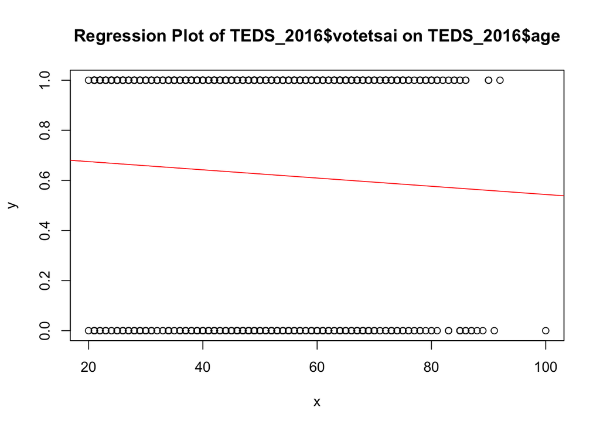

```r
# Run regplot for Age, Education, and Income against votetsai
regplot(TEDS_2016$age, TEDS_2016$votetsai)
```

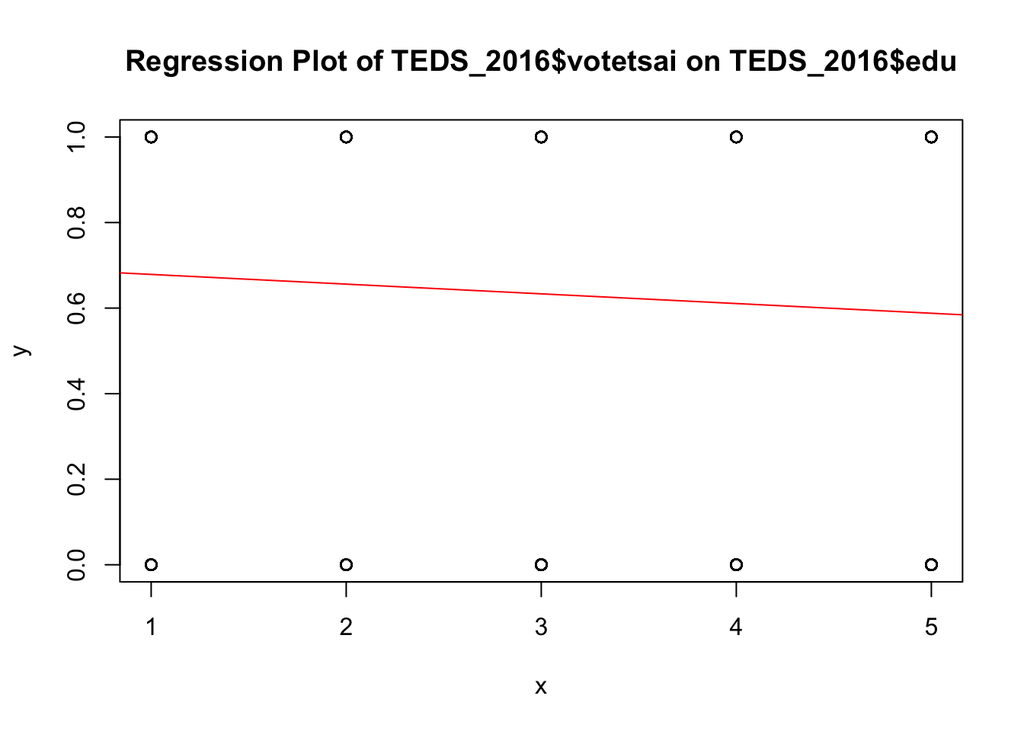

```r
regplot(TEDS_2016$edu, TEDS_2016$votetsai)
```

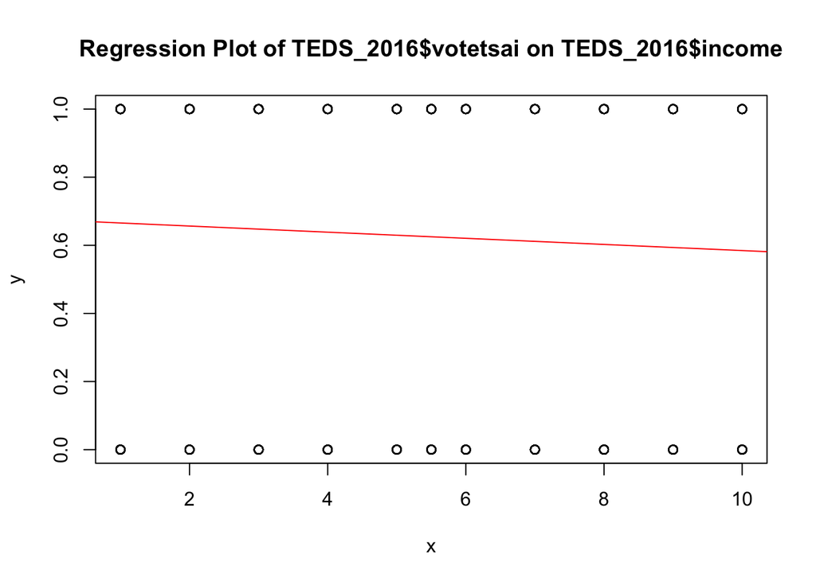

```r
regplot(TEDS_2016$income, TEDS_2016$votetsai)
```

```r
# If `votetsai` is binary, consider logistic regression instead
fit_logit <- glm(votetsai ~ age + edu + income, data = TEDS_2016, family = binomial)
summary(fit_logit)
```

```
##
## Call:
## glm(formula = votetsai ~ age + edu + income, family = binomial,
##     data = TEDS_2016)
##
## Coefficients:
##              Estimate Std. Error z value Pr(>|z|)
## (Intercept)  2.508583   0.379569   6.609 3.87e-11 ***
## age         -0.021731   0.004656  -4.668 3.05e-06 ***
## edu         -0.238448   0.054069  -4.410 1.03e-05 ***
## income      -0.020470   0.022460  -0.911    0.362
## ---
## Signif. codes:  0 '***' 0.001 '**' 0.01 '*' 0.05 '.' 0.1 ' ' 1
##
## (Dispersion parameter for binomial family taken to be 1)
##
##     Null deviance: 1661.8  on 1256  degrees of freedom
## Residual deviance: 1632.0  on 1253  degrees of freedom
##   (433 observations deleted due to missingness)
## AIC: 1640
##
## Number of Fisher Scoring iterations: 4
```

### **Regression Plot Function**

A function named **`regplot`** was developed to facilitate the plotting of regression lines for various explanatory variables against a chosen dependent variable. This function integrates the **`lm`**, **`plot`**, and **`abline`** functions to create a clear visual representation of the relationship between two variables.

### **Regression Analysis**

Multiple regression plots were generated using the **`regplot`** function to examine the effects of age, education, and income on the likelihood of voting for Tsai Ing-wen:

- **Age:** The regression analysis suggested a negative relationship, indicating that younger individuals were more likely to vote for Tsai Ing-wen.
- **Education:** Higher education levels appeared to decrease the likelihood of voting for Tsai, possibly reflecting different political leanings across educational groups.
- **Income:** The relationship was less clear, with no significant effect observed in the preliminary regression analysis.

### **Challenges Encountered**

The primary challenge was dealing with the binary nature of the dependent variable (**`votetsai`**), which indicates whether respondents voted for Tsai Ing-wen (1) or not (0). Standard linear regression is not well-suited for binary outcomes, which led to the consideration of logistic regression.

### **Logistic Regression**

Given the binary outcome of the dependent variable, a logistic regression model was more appropriate. This model showed:

- **Age** and **education** significantly affected the probability of voting for Tsai, with both showing negative coefficients, suggesting that younger, less educated individuals were more likely to vote for Tsai.
- **Income** did not significantly influence voting behavior, indicating economic status might not be a strong predictor in this electoral context.

### **Conclusion**

The exploratory data analysis provided valuable insights into the factors influencing voting behavior in Taiwan. The custom **`regplot`** function proved useful for visualizing these relationships, although the analysis highlighted the importance of choosing appropriate models for the nature of the data. Future analyses could expand on these findings by incorporating additional variables or using different subsets of the data to further uncover the dynamics of voter preferences.

### **Recommendations**

- Further exploration with more complex models like multinomial logistic regression could be considered if the dependent variable categories expand beyond binary choices.
- Additional variables such as geographical location or more detailed income brackets could be included to enhance the model’s predictive power and accuracy.

This analysis serves as a foundational step in understanding the interplay between socio-economic factors and political preferences, offering a methodological framework for future studies in similar contexts.